# Reproducible Research: Peer Assessment 1

Charles

Wednesday, November 12, 2014

## Loading and preprocessing the data

### 1 Preparing the packages

### 2. Downloading the data set

Warning:

- https is a problem for R in many cases, so you need to use a package like RCurl to get around it.
- So the problem is that R does not allow connections to https URL’s.You can use download.file with curl
1. Set your work directory
- Read activity.csv
- Format columns

```
##   steps       date interval
## 1    NA 2012-10-01        0
## 2    NA 2012-10-01        5
## 3    NA 2012-10-01       10
## 4    NA 2012-10-01       15
## 5    NA 2012-10-01       20
## 6    NA 2012-10-01       25
```

```
##   steps       date interval
## 1    NA 2012-10-01        0
## 2    NA 2012-10-01        5
## 3    NA 2012-10-01       10
## 4    NA 2012-10-01       15
## 5    NA 2012-10-01       20
## 6    NA 2012-10-01       25
```

### 3.What is mean total number of steps taken per day?

For this part of the assignment, you can ignore the missing values in the dataset.

1. Make a histogram of the total number of steps taken each day

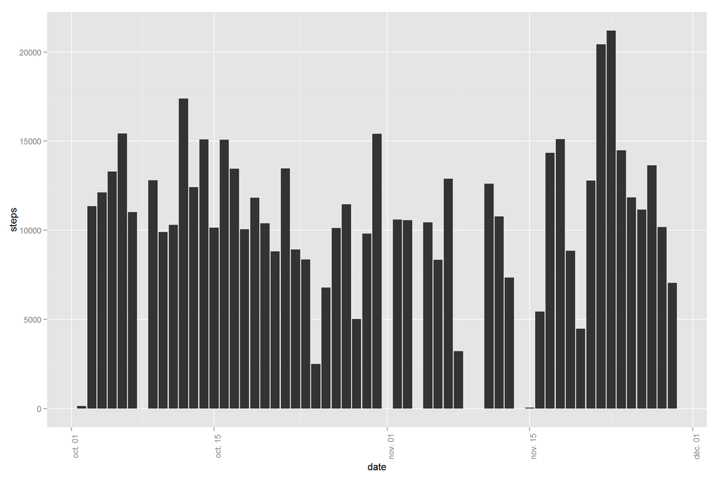

2. Calculate and report the mean and median total number of steps taken per day

```
##       date                steps
##  Min.   :2012-10-02   Min.   :   41
##  1st Qu.:2012-10-16   1st Qu.: 8841
##  Median :2012-10-29   Median :10765
##  Mean   :2012-10-30   Mean   :10766
##  3rd Qu.:2012-11-16   3rd Qu.:13294
##  Max.   :2012-11-29   Max.   :21194
```

```
## [1] 10766.19
```

```
## [1] 10765
```

### 4.What is the average daily activity pattern?

1. Make a time series plot (i.e. type = “l”) of the 5-minute interval (x-axis) and the average number of steps taken, averaged across all days (y-axis)

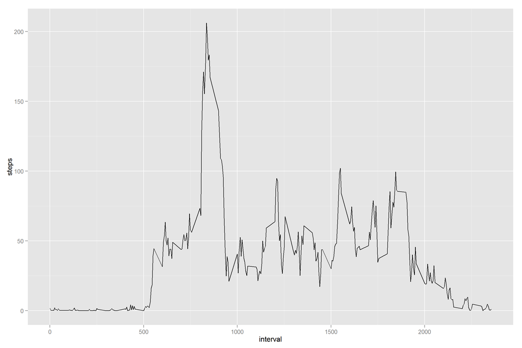

2. Which 5-minute interval, on average across all the days in the dataset, contains the maximum number of steps?

```
##     interval    steps
## 104      835 206.1698
```

### 5.Imputing missing values

1. Calculate and report the total number of missing values in the dataset (i.e. the total number of rows with NAs)
2. Devise a strategy for filling in all of the missing values in the dataset. The strategy does not need to be sophisticated. For example, you could use the mean/median for that day, or the mean for that 5-minute interval, etc.
- To identify the interval which have at least one record with an age missing, I’ll use the bystats function from the Hmisc package.
- I will also include the mean for each interval, in order to allocate the mean of interval to the missing value of each interval
3. Create a new dataset that is equal to the original dataset but with the missing data filled in.

```
##   StepClean steps       date interval
## 1     1.717    NA 2012-10-01        0
## 2     0.340    NA 2012-10-01        5
## 3     0.132    NA 2012-10-01       10
## 4     0.151    NA 2012-10-01       15
## 5     0.075    NA 2012-10-01       20
## 6     2.094    NA 2012-10-01       25
```

[figure not shown]

5. What is the impact of imputing missing data on the estimates of the total daily number of steps?

```
##               Min. 1st Qu. Median Mean 3rd Qu. Max. NA's
## stepswithNA      0       0      0   37      12  806 2304
## stepswthoutNA    0       0      0   37      27  806    0
```

### 6.Are there differences in activity patterns between weekdays and weekends?

1. For this part the weekdays() function may be of some help here. Use the dataset with the filled-in missing values for this part.
2. Create a new factor variable in the dataset with two levels - “weekday” and “weekend” indicating whether a given date is a weekday or weekend day.
3. Create a new dataset that is equal to the original dataset but with the missing data filled in.

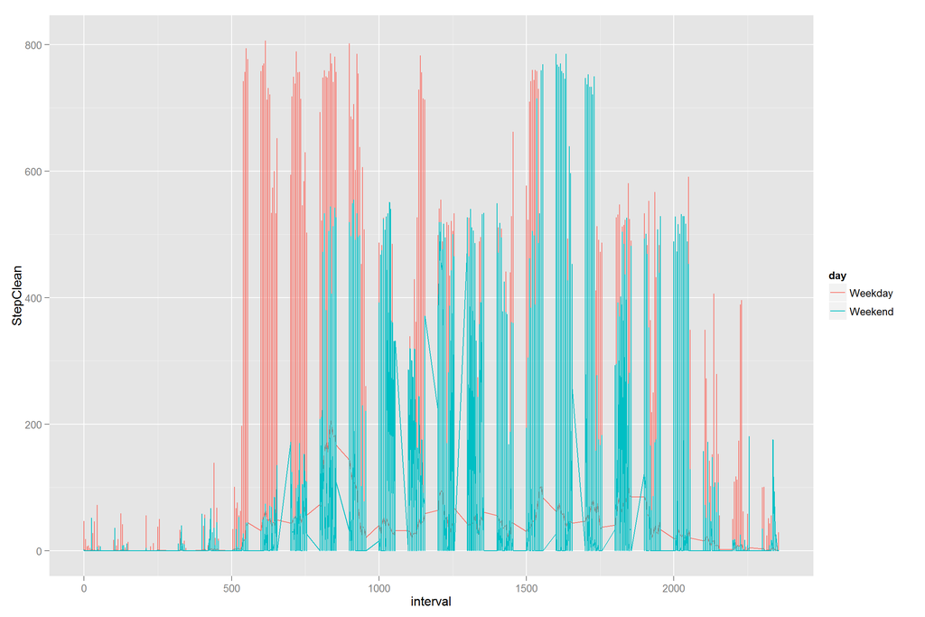